# Teste de hipóteses para o vetor de média no conjunto de dados do Mc Donalds

Gabriel Pereira e Luiz Paulo

2020/10

Os pacotes que serão usados durante a análise são os que estão abaixo. Logo em segue temos a importação do conjunto de dados nutricionais do Mc Donalds utilizando o pacote readr.

```r
library(readr)
library(car)
library(tidyverse)
library(nortest)
library(MVN)
library(psych)
library(lares)

DadosNutricionaisMcDonalds <- read_delim("C:/Users/55119/Desktop/multivariate/datasets/DadosNutricionaisMcDonalds.txt", ";", escape_double = FALSE, trim_ws = TRUE)
```

Para termos uma noção das variáveis e o que as mesmas representam, vejamos as primeiras linhas desse data frame.

```r
head(DadosNutricionaisMcDonalds)
```

```
## # A tibble: 6 x 12
##   Tipo  Nome  Calorias Carboidratos Proteinas Gorduras GordurasSat Colesterol
##   <chr> <chr>    <dbl>        <dbl>     <dbl>    <dbl>       <dbl>      <dbl>
## 1 Sand~ BigM~      490           45        23       25           9         70
## 2 Sand~ Quar~      500           37        30       26          12         90
## 3 Sand~ McCh~      380           44        16       15           3         40
## 4 Sand~ Ched~      460           36        28       23          10         80
## 5 Sand~ McNí~      500           10        37       35          14        135
## 6 Sand~ McFi~      440           41        19       22           6         45
## # ... with 4 more variables: Fibras <dbl>, Calcio <chr>, Ferro <chr>,
## #   Sodio <dbl>
```

Temos então 12 variáveis, algumas variáveis que seus valores são Strings e as demais são int ou float, porém todas as fazem referêcia aos lanches quanto seus valores nutricionais. Visto a “cabeça” do conjunto de dados do Mc Donalds e as variáveis presente, segue entao a remoção do tipo do produto que são diferentes de $\textit{sanduíches}$.

```r
sanduiches = filter(DadosNutricionaisMcDonalds, Tipo == "Sanduiches")
sanduiches = sanduiches[,-1]

for (i in 1:15) {
  for (j in 9:10) {
    sanduiches[i,j] = gsub(",",".", sanduiches[i,j])
  }
}

sanduiches$Calcio = as.numeric(sanduiches$Calcio)
sanduiches$Ferro = as.numeric(sanduiches$Ferro)
```

Acima também retiramos a coluna Tipo do alimento, já que como filtramos somente os sanduíches. Vejamos então algumas estatísticas descritivas das variáveis,

```r
describe(sanduiches[,-1])[,c(3,4,5,8,9)]
```

```
##                mean     sd median   min    max
## Calorias     402.00 133.32  380.0 230.0  760.0
## Carboidratos  32.73   9.04   31.0  10.0   45.0
## Proteinas     21.40   8.92   21.0  10.0   38.0
## Gorduras      20.67  10.69   21.0   7.0   49.0
## GordurasSat    7.40   5.37    5.0   2.0   22.0
## Colesterol    61.33  33.03   55.0  25.0  135.0
## Fibras         2.07   0.88    2.0   1.0    5.0
## Calcio       101.91  80.64   93.7  14.3  282.0
## Ferro          2.50   1.75    2.0   0.7    8.1
## Sodio        857.33 226.42  890.0 440.0 1170.0
```

Podemos ver acima que a média de calorias dos sanduíches é 400kcal, com um desvio padrão alto, indicando que temos sanduiches com bastante caloria e outros com poucas calorias, além disso, outro motivo é a dispersão desses valores, provavelmente estão distantes um dos outros e podemos ver que o mesmo ocorre com o sódio. No geral as medianas estão próximas das médias. Abaixo temos as correlações,

```r
corr_cross(sanduiches[,-1],
  max_pvalue = 0.05,
  method = "pearson",
  quiet = F
)
```

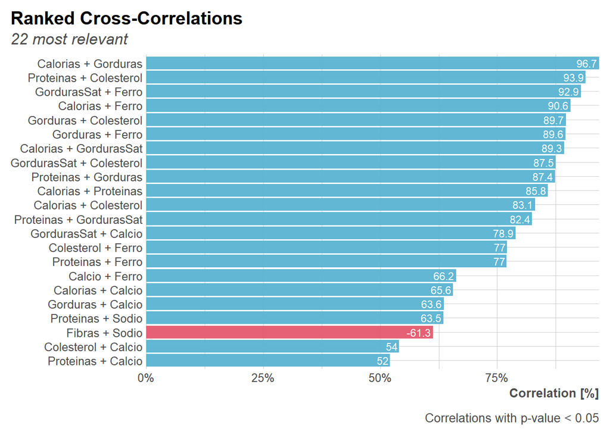

## Normalidade

```r
mvn(sanduiches[,-1], mvnTest = "royston", multivariatePlot = "qq",
    univariateTest = "AD")$multivariateNormality
```

```
##      Test        H      p value MVN
## 1 Royston 31.93226 9.656211e-06  NO
```

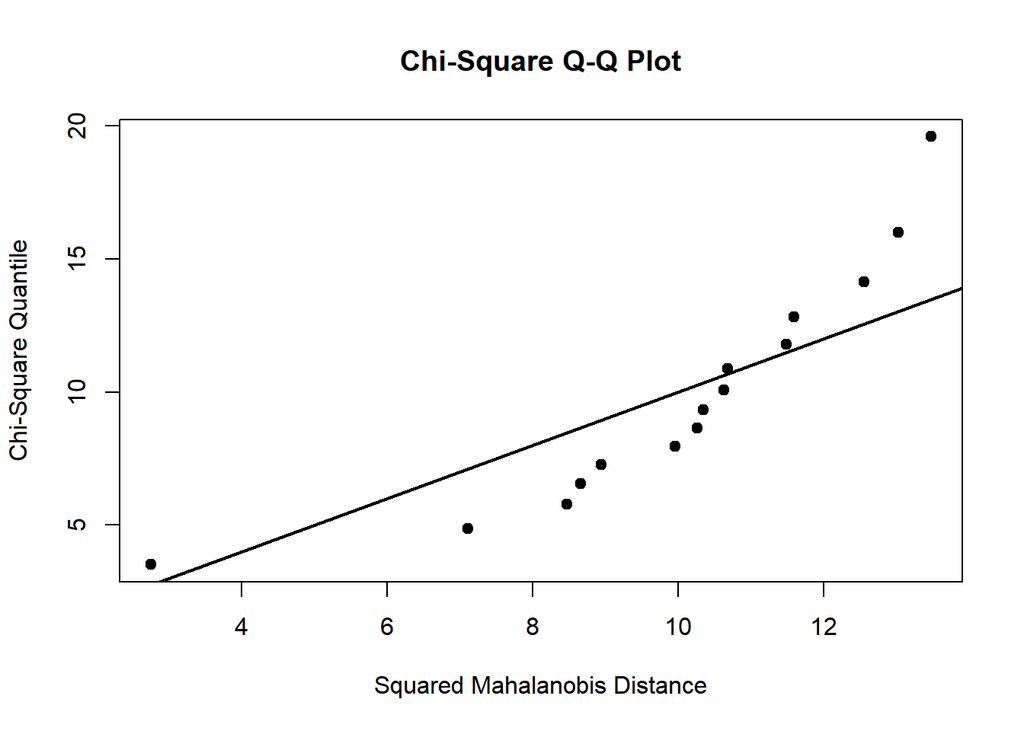

```
##              Test         Statistic            p value Result
## 1 Mardia Skewness  226.725951106577    0.3634900695397    YES
## 2 Mardia Kurtosis -1.66910837568638 0.0950959036949925    YES
## 3             MVN              <NA>               <NA>    YES
```

```r
mvn(sanduiches[,-1], mvnTest = "mardia", multivariatePlot = "qq",
    univariateTest = "AD")$multivariateNormality
```

```r
mvn(sanduiches[,-1], mvnTest = "mardia", multivariatePlot = "qq",
    univariateTest = "AD")$univariateNormality
```

```
##                Test     Variable Statistic   p value Normality
## 1  Anderson-Darling   Calorias      0.4282  0.2702      YES
## 2  Anderson-Darling Carboidratos    0.4654  0.2167      YES
## 3  Anderson-Darling  Proteinas      0.3454  0.4344      YES
## 4  Anderson-Darling   Gorduras      0.5246  0.1513      YES
## 5  Anderson-Darling GordurasSat     0.8604  0.0203      NO
## 6  Anderson-Darling  Colesterol     0.5772  0.1117      YES
## 7  Anderson-Darling    Fibras       3.3202  <0.001      NO
## 8  Anderson-Darling    Calcio       0.5259  0.1501      YES
## 9  Anderson-Darling    Ferro        1.3543   0.001      NO
## 10 Anderson-Darling    Sodio        0.2708  0.6217      YES
```

## Transformação de variáveis

Com a rejeição da hipótese de normalidade multivariada, seguiremos então com a tentativa de normalização através de Box-Cox, como o método interativo para encontrar os valores de $\textit{lambda}$ são um tanto complexos, tenhamos então,

```r
lambda = powerTransform(sanduiches[, -1],family = "bcnPower")$lambda

box_cox <- function(x, lambda) {
  for (i in 1:length(lambda)) {
    if(lambda[i] == 0){
      x[,i] = log(x[,i], base = exp(1))
    }else{
      x[,i] = (x[,i]^lambda[i] - 1)/lambda[i]
    }
  }
  return(x)
}
bcSanduiches <- box_cox(sanduiches[,-1], lambda)

mvn(bcSanduiches, mvnTest = "royston", multivariatePlot = "qq")$multivariateNormality
```

```
##      Test        H      p value MVN
## 1 Royston 55.42933 1.821962e-09  NO
```

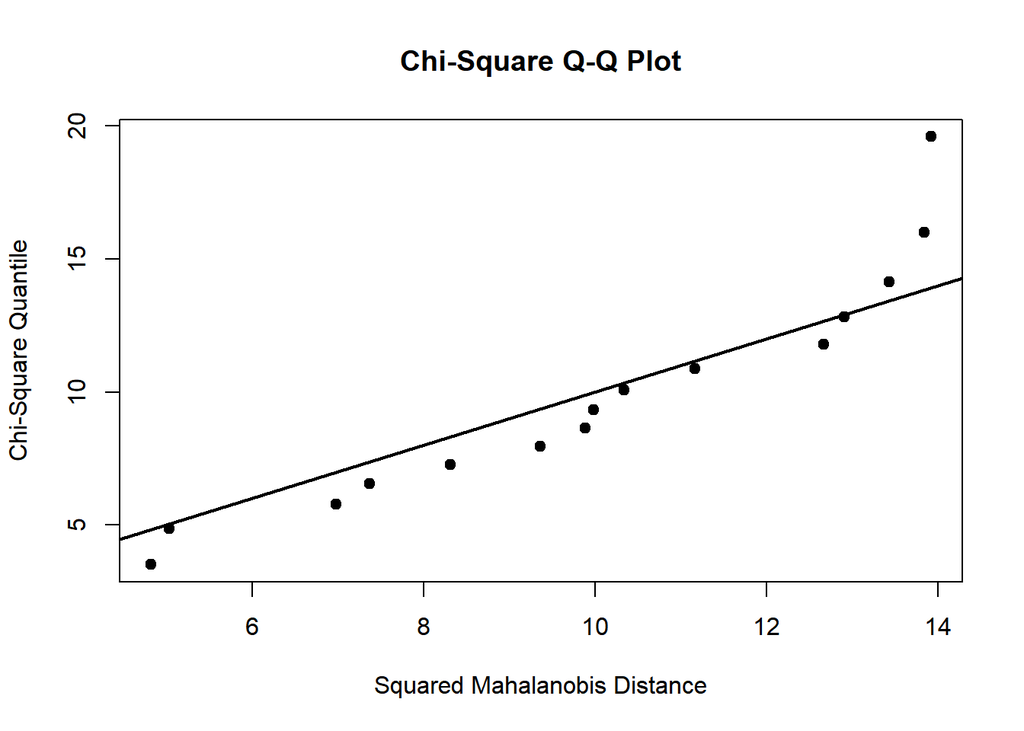

```
##            Test     Variable Statistic   p value Normality
## 1  Shapiro-Wilk   Calorias      0.8251  0.0079      NO
## 2  Shapiro-Wilk Carboidratos    0.7498   9e-04      NO
## 3  Shapiro-Wilk  Proteinas      0.9351  0.3252      YES
## 4  Shapiro-Wilk   Gorduras      0.8087  0.0048      NO
## 5  Shapiro-Wilk GordurasSat     0.9793  0.9643      YES
## 6  Shapiro-Wilk  Colesterol     0.9375  0.3521      YES
## 7  Shapiro-Wilk    Fibras       0.4981  <0.001      NO
## 8  Shapiro-Wilk    Calcio       0.8983  0.0895      YES
## 9  Shapiro-Wilk    Ferro        0.5894  <0.001      NO
## 10 Shapiro-Wilk    Sodio        0.9599  0.6901      YES
```

```r
mvn(bcSanduiches, mvnTest = "royston", multivariatePlot = "qq")$univariateNormality
```

```r
mvn(bcSanduiches, mvnTest = "mardia", multivariatePlot = "qq")$multivariateNormality
```

```
##              Test         Statistic            p value Result
## 1 Mardia Skewness  253.616405395706 0.0595031590311763    YES
## 2 Mardia Kurtosis -1.41833038039715   0.15609433093847    YES
## 3             MVN              <NA>               <NA>    YES
```

```r
mvn(bcSanduiches, mvnTest = "mardia", multivariatePlot = "qq")$univariateNormality
```

```
##            Test     Variable Statistic   p value Normality
## 1  Shapiro-Wilk   Calorias      0.8251  0.0079      NO
## 2  Shapiro-Wilk Carboidratos    0.7498   9e-04      NO
## 3  Shapiro-Wilk  Proteinas      0.9351  0.3252      YES
## 4  Shapiro-Wilk   Gorduras      0.8087  0.0048      NO
## 5  Shapiro-Wilk GordurasSat     0.9793  0.9643      YES
## 6  Shapiro-Wilk  Colesterol     0.9375  0.3521      YES
## 7  Shapiro-Wilk    Fibras       0.4981  <0.001      NO
## 8  Shapiro-Wilk    Calcio       0.8983  0.0895      YES
## 9  Shapiro-Wilk    Ferro        0.5894  <0.001      NO
## 10 Shapiro-Wilk    Sodio        0.9599  0.6901      YES
```

```r
mvn(bcSanduiches, mvnTest = "hz", multivariatePlot = "qq")$multivariateNormality
```

```
##            Test       HZ     p value MVN
## 1 Henze-Zirkler 1.004314 0.001666913  NO
```

```r
mvn(bcSanduiches, mvnTest = "hz", multivariatePlot = "qq")$univariateNormality
```

```
##            Test     Variable Statistic   p value Normality
## 1  Shapiro-Wilk   Calorias      0.8251  0.0079      NO
## 2  Shapiro-Wilk Carboidratos    0.7498   9e-04      NO
## 3  Shapiro-Wilk  Proteinas      0.9351  0.3252      YES
## 4  Shapiro-Wilk   Gorduras      0.8087  0.0048      NO
## 5  Shapiro-Wilk GordurasSat     0.9793  0.9643      YES
## 6  Shapiro-Wilk  Colesterol     0.9375  0.3521      YES
## 7  Shapiro-Wilk    Fibras       0.4981  <0.001      NO
## 8  Shapiro-Wilk    Calcio       0.8983  0.0895      YES
## 9  Shapiro-Wilk    Ferro        0.5894  <0.001      NO
## 10 Shapiro-Wilk    Sodio        0.9599  0.6901      YES
```

```r
mvn(bcSanduiches, mvnTest = "dh", multivariatePlot = "qq")$multivariateNormality
```

```
##             Test        E df       p value MVN
## 1 Doornik-Hansen 610.7426 20 1.568773e-116  NO
```

```r
mvn(bcSanduiches, mvnTest = "dh", multivariatePlot = "qq")$univariateNormality
```

```
##            Test     Variable Statistic   p value Normality
## 1  Shapiro-Wilk   Calorias      0.8251  0.0079      NO
## 2  Shapiro-Wilk Carboidratos    0.7498   9e-04      NO
## 3  Shapiro-Wilk  Proteinas      0.9351  0.3252      YES
## 4  Shapiro-Wilk   Gorduras      0.8087  0.0048      NO
## 5  Shapiro-Wilk GordurasSat     0.9793  0.9643      YES
## 6  Shapiro-Wilk  Colesterol     0.9375  0.3521      YES
## 7  Shapiro-Wilk    Fibras       0.4981  <0.001      NO
## 8  Shapiro-Wilk    Calcio       0.8983  0.0895      YES
## 9  Shapiro-Wilk    Ferro        0.5894  <0.001      NO
## 10 Shapiro-Wilk    Sodio        0.9599  0.6901      YES
```

Como vemos acima, os testes de Henze-Zirkler, Doornik-Hansen, Royston rejeitaram a hipótese de normalidade multivariada, com $\textit{valores-p}$ bem baixo. Somente os teste de Mardia não rejeitaram a hipótese nula, porém em todos os testes, algumas marginais não estão normalizadas, seguirei a partir daqui com a normalização das marginais e depois o teste de normalidade multivariada. A primeira transformação a ser feita é $ln(Ferro)$, a segunda transformação será a Box-Cox para a variável $\textit{Gorduras Saturadas}$, visto que esta alcançou a normalidade por este método,

```r
sanduichesNormalizadasUmaAUma <- sanduiches[,-1]
sanduichesNormalizadasUmaAUma$Ferro <- log(sanduiches$Ferro)
sanduichesNormalizadasUmaAUma$GordurasSat <- bcSanduiches$GordurasSat
```

Depois de normalizadas algumas marginais, sobrou somente a variável $\textit{Fibras}$ que possui muitas observações iguais, dificultando qualquer transformação pois o padrão continuar o mesmo

```r
sanduiches$Fibras
```

```
##  [1] 2 1 2 1 2 2 2 2 2 2 2 2 2 5 2
```

Verificando o teste de normalidade multivariada,

```r
mvn(sanduichesNormalizadasUmaAUma, mvnTest = "royston", multivariatePlot = "qq")$multivariateNormality
```

```
##      Test        H      p value MVN
## 1 Royston 25.12377 0.0004595339  NO
```

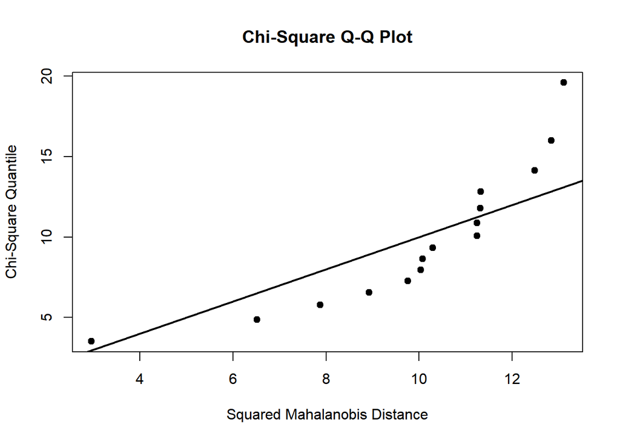

```
##              Test         Statistic            p value Result
## 1 Mardia Skewness  223.861597932052  0.414972910050844    YES
## 2 Mardia Kurtosis -1.68289156066516 0.0923960856252672    YES
## 3             MVN              <NA>               <NA>    YES
```

```r
mvn(sanduichesNormalizadasUmaAUma, mvnTest = "mardia", multivariatePlot = "qq")$multivariateNormality
```

```r
mvn(sanduichesNormalizadasUmaAUma, mvnTest = "hz", multivariatePlot = "qq")$multivariateNormality
```

```
##            Test        HZ   p value MVN
## 1 Henze-Zirkler 0.9644855 0.1616987 YES
```

```r
mvn(sanduichesNormalizadasUmaAUma, mvnTest = "dh", multivariatePlot = "qq")$multivariateNormality
```

```
##             Test        E df      p value MVN
## 1 Doornik-Hansen 192.4966 20 3.410461e-30  NO
```

```r
mvn(sanduichesNormalizadasUmaAUma, mvnTest = "energy", multivariatePlot = "qq")$multivariateNormality
```

```
##          Test Statistic p value MVN
## 1 E-statistic  1.580118   0.386 YES
```

Após as transformações alguns os pontos não caem sobre uma reta e dado que alguns 2 testes ainda estão rejeitando e 3 estão aceitando a normalidade multivariada, e temos somente uma variável que não segue a distribuição normal marginal, seguiremos então com o teste de Hotelling

Para testar as hipóteses $H_0: \mu = \mu_0$ versus $H_1: \mu \neq \mu_0$ em que $\mu_0$ é um vetor médias hipotético, temos que a estatística de teste é
$$\begin{align*}
T^2 = \sqrt{n}(\bar{X} - \mu_0)'(\frac{\sum_{i = 1}^{n} (X_j - \bar{X})(X_j - \bar{X})'}{n-1})^{-1}\sqrt{n}(\bar{X} - \mu_0)
\end{align*}$$
tal que,
$$\begin{align*}
T^2 > \frac{(n-1)p}{n-p}F_{p,n-p}(\alpha)
\end{align*}$$
Utilizando como vetor de médias hipotético um vetor contendo as medianas, temos que o teste de Hotelling,

```r
n = length(sanduichesNormalizadasUmaAUma$Calorias)
p = length(colnames(sanduichesNormalizadasUmaAUma))
xbar = colMeans(sanduichesNormalizadasUmaAUma)
mu_0 = as.matrix(describe(sanduichesNormalizadasUmaAUma)[,5], ncol = 1)
t = n*t(xbar - mu_0)%*%solve(var(sanduichesNormalizadasUmaAUma))%*%(xbar - mu_0)
valorP <- pf(((n-p)/(n-1)*p)*t, p, n-p, lower.tail = F)
valorP
```

```
##              [,1]
## [1,] 3.028959e-08
```